# Reproducible Research: Peer Assessment 1

## Loading and preprocessing the data

1. Load the data (i.e. `read.csv()`). Data loaded into R using `unzip` and `read.csv`.

```r
unzip("activity.zip")
data <- read.csv("activity.csv", header = TRUE, na.strings = "NA")
```

2. Process/transform the data (if necessary) into a format suitable for your analysis.  
   Date variable is transformed from factor to Date.

```r
data$date <- as.Date(data$date)
```

## What is mean total number of steps taken per day?

1. Make a histogram of the total number of steps taken each day. `NA` values are to be ignored, histogram showing total number of steps taken per day is shown below.

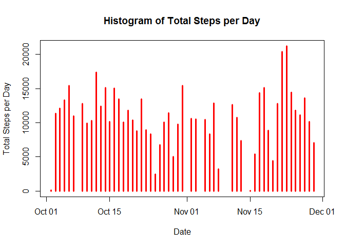

```r
# load reshape2 and ggplot2 packages
require(reshape2)
require(ggplot2)
melt_data <- melt(data, id.vars = "date", na.rm = TRUE, measure.vars = "steps")

cast_data <- dcast(melt_data, date ~ variable, sum)

# Plot histogram
plot(cast_data$date, cast_data$steps, type = "h", main = "Histogram of Total Steps per Day", xlab = "Date", ylab = "Total Steps per Day", col = "red", lwd = 3)
```

```r
mean_steps <- mean(cast_data$steps, na.rm = TRUE)
median_steps <- median(cast_data$steps, na.rm = TRUE)
```

## What is the average daily activity pattern?

1. Show time series plot of the 5 min interval (x-axis) and the average number of steps taken, averaged across all days (y-axis).

[figure not shown]

```r
Interval_data_melt <- melt(data, id.vars="interval", measure.vars="steps", na.rm=TRUE)

Interval_data_cast <- dcast(Interval_data_melt, interval ~ variable, mean)

# plot with line that shows mean
plot(Interval_data_cast$interval, Interval_data_cast$steps, type="l", main="Avg Number of Steps Taken at Each Interval", xlab="Interval", ylab="Steps", col="blue")
abline(h=mean(Interval_data_cast$steps, na.rm=TRUE), col="red")
```

2. Which 5-minute interval, on average across all the days in the dataset, contains the maximum number of steps?

```r
max_steps_int <- Interval_data_cast$interval[which(Interval_data_cast$steps == max(Interval_data_cast$steps))]

max_steps <- max(Interval_data_cast$steps)
```

The interval with the highest number of steps is 835.  
The maximum number of mean steps is 206.1698113.

## Imputing missing values

There are a number of days/intervals where there are missing values (coded as `NA`). The presence of missing days may introduce bias into some calculations or summaries of the data.

1. Calculate and report the total number of missing values in the dataset (i.e. the total number of rows with `NA`s).

```r
na_count <- sum(is.na(data$steps))
```

The total number of `NA`s is 2304

2. Devise a strategy for filling in all of the missing values in the dataset. The strategy does not need to be sophisticated. For example, you could use the mean/median for that day, or the mean for that 5-minute interval, etc.

The method used will assign the average number of steps for each interval into those intervals with `NA`s.

After this a histogram, mean and median will be created as in section 2.

3. Create a new dataset that is equal to the original dataset but with the missing data filled in.  
   Strategy implemented to fill in `NA` values.

```r
# creat new data set without NAs
Steps_per_int <- Interval_data_cast

data_filled <- data

data_merge = merge(data_filled, Steps_per_int, by="interval", suffixes=c(".b4", ".aftr"))

naIndex = which(is.na(data_filled$steps))

data_filled[naIndex,"steps"] = data_merge[naIndex,"steps.aftr"]
```

4. Make a histogram of the total number of steps taken each day and Calculate and report the mean and median total number of steps taken per day.

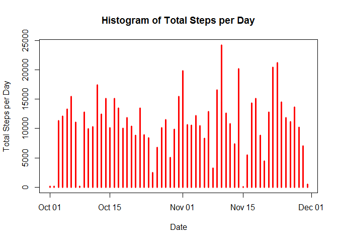

```r
# load reshape2 and ggplot2 packages
require(reshape2)
require(ggplot2)

data_filled_melt <- melt(data_filled, id.vars="date", measure.vars="steps")

data_filled_cast <- dcast(data_filled_melt, date ~ variable, sum)

# Plot histogram
plot(data_filled_cast$date, data_filled_cast$steps, type = "h", main = "Histogram of Total Steps per Day", xlab = "Date", ylab = "Total Steps per Day", col = "red", lwd = 3)
```

```r
# recalculate mean for data with missing values replaced

mean_steps2 <- mean(data_filled_cast$steps, na.rm = TRUE)
median_steps2 <- median(data_filled_cast$steps, na.rm = TRUE)

mean_diff <- mean_steps2 - mean_steps
median_diff <- median_steps2 - median_steps
```

Do these values differ from the estimates from the first part of the assignment?

Yes, the values have increased for both mean and meadian.

The mean has increased by 123.6105784.  
The median has incread by 250.

What is the impact of imputing missing data on the estimates of the total daily number of steps?

```r
Interval_datafilled_melt <- melt(data_filled, id.vars="interval", measure.vars="steps")

Interval_datafilled_cast <- dcast(Interval_datafilled_melt, interval ~ variable, mean)

max_stepsfilled_int <- Interval_datafilled_cast$interval[which(Interval_datafilled_cast$steps == max(Interval_datafilled_cast$steps))]

max_steps_filled <- max(Interval_datafilled_cast$steps)

max_diff <- max_steps - max_steps_filled
```

The interval with the highest number of steps is 835.  
The maximum number of mean steps is 184.7073925.

The maximum number of mean steps has now decreased by 21.4624188.